# Comparison of proportional hazards and accelerated failure time models in analysing factors associated with having the COVID-19 vaccination

## Purpose

(Taken from https://docs.google.com/document/d/1PZgllPNU8zi2xVPrPDHoBxzQGti7F3C7R9AyqGkKAJU/edit)

Firstly, and obviously, we are not trying to directly estimate the causal effect of any one putative cause on vaccination propensity/timing/uptake. This requires statistical models tailored to each specific causal effect of interest, which we are not doing here. Essentially, we are not providing answers to “what if” questions.

Secondly, it is not feasible to use this model to make predictions about vaccination uptake in the future. The vaccination programme is far too dynamic over time; target populations for vaccination quickly shift from one priority group to the next, vaccine availability will change over time, new policies are introduced in response to emerging evidence about effectiveness, safely, covid risk, inequalities, etc. It is also susceptible to the Prediction Paradox, i.e., predictions influencing policies or behaviors which then invalidates the predictions. This means predictive performance should not be considered important, and we should not be providing individualised risk scores.

What is possible, and informative, is to use the model to describe observed differences in vaccine uptake across different patient groups, strictly over the studied period. In particular, this can help to probe apparent inequalities. Not to prove or disprove -- that would require a causal investigation -- but to identify systematic variation in uptake which is not sufficiently accounted for by other modelled factors.

## Statistical analysis

### Background

- The initial plan was to use Cox proportional hazards (PH) regression to model FAW COVID vaccine
- The main assumption of the PH model is that the hazard ratio is constant over time
- Violation of this assumption may lead to several statistical problems such as misinterpretation of the estimation results and reducing the power of the related statistical tests
- Accelerated failure time (AFT) models can be used as an alternative to a PH model, especially to overcome the statistical problems due to the violation of PH assumption
- The AFT model accounts for the effects of the covariates directly on survival times instead of the hazards rate as in the PH model
- The interpretation of the results in AFT model is therefore arguable easier than the results of PH model because the parameters indicate the effect of the explanatory variables on the mean survival time

### Methods

1. The log cumulative hazard plots approach and Schoenfeld residual statistical test were applied to the data set in order to examine the existence of non-PH
2. A coxPH model, Weibull AFT model, exponential AFT model, and log-normal AFT model were fitted to the data set
3. The fit of the models was compared using probability plots, Akaike information criterion (AIC) and Bayesian information criterion (BIC), smaller value of which indicate better fit

## Results

### Participants

A total of 1577431 individuals were female (54.4%) and mean age of individuals was 77.7 (SD 6.1) years. The median (25th, 75th percentiles) time to vaccination was 50 (40, 59) days.

### Assessing the proportional hazards assumption

Two approaches were used to identify the presence of non-proportional hazards: 1) log cumulative hazard plots and 2) goodness of fit (GOF) testing.

#### 1. Log cumulative hazard plots

In order to identify the presence of non-proportional hazards, it is common to use log cumulative hazard plots. If the plot does not yield parallel curves over the log(time), then the PH assumption is not correct (i.e., the PH assumption is violated in the model).

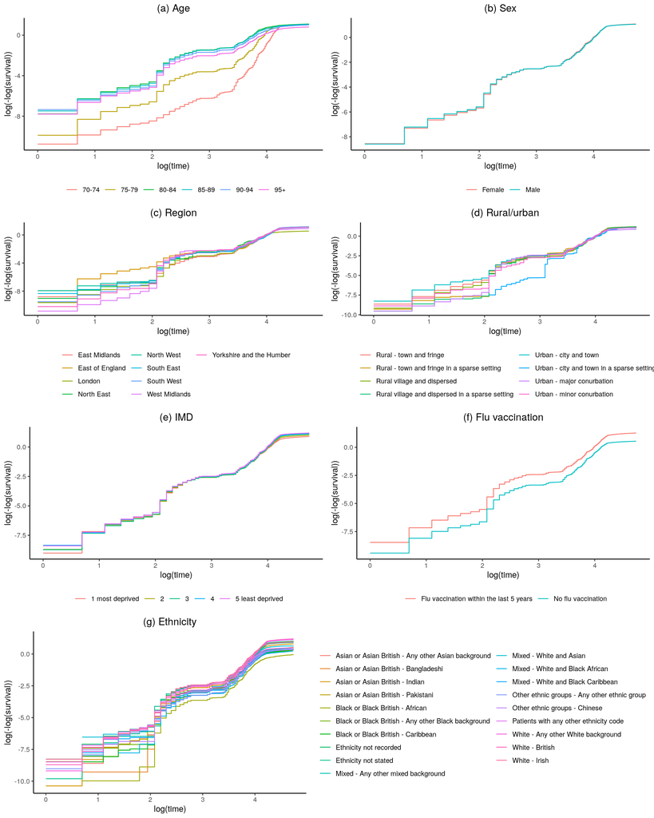

Figure 1: The log cumulative hazard plots of categorical covariates

#### 2. Goodness of fit (GOF) testing approach

The basic idea of the GOF test is that if the PH assumption for a covariate is not violated, there is no correlation between the Schoenfeld residuals and the vaccination time.

|  | P-value Kaplan-Meier | P-value Log(time) | P-value Time |
| --- | --- | --- | --- |
| ageband | <0.0001 | <0.0001 | <0.0001 |
| sex | <0.0001 | <0.0001 | <0.0001 |
| ethnicity | <0.0001 | <0.0001 | <0.0001 |
| morbid_obesity | <0.0001 | <0.0001 | <0.0001 |
| chronic_heart_disease | <0.0001 | <0.0001 | <0.0001 |
| diabetes | <0.0001 | <0.0001 | <0.0001 |
| chronic_kidney_disease_diagnostic | <0.0001 | <0.0001 | <0.0001 |
| chronic_kidney_disease_all_stages | <0.0001 | <0.0001 | <0.0001 |
| chronic_kidney_disease_all_stages_3_5 | <0.0001 | <0.0001 | <0.0001 |
| sev_mental_ill | <0.0001 | <0.0001 | <0.0001 |
| learning_disability | <0.0001 | <0.0001 | <0.0001 |
| chronic_neuro_dis_inc_sig_learn_dis | <0.0001 | <0.0001 | <0.0001 |
| asplenia | <0.0001 | 0.0017 | <0.0001 |
| chronic_liver_disease | <0.0001 | <0.0001 | <0.0001 |
| chronis_respiratory_disease | <0.0001 | <0.0001 | <0.0001 |
| immunosuppression_diagnosis | <0.0001 | <0.0001 | <0.0001 |
| immunosuppression_medication | <0.0001 | <0.0001 | <0.0001 |
| imd | <0.0001 | <0.0001 | 0.0001 |
| rural_urban | <0.0001 | <0.0001 | <0.0001 |
| prior_covid | <0.0001 | <0.0001 | <0.0001 |
| flu_vaccine | <0.0001 | <0.0001 | <0.0001 |
| shielded | <0.0001 | <0.0001 | <0.0001 |
| shielded_since_feb_15 | <0.0001 | <0.0001 | <0.0001 |
| GLOBAL | <0.0001 | <0.0001 | <0.0001 |

### Comparison of the PH model and the AFT models

| Model | AIC | BIC |
| --- | --- | --- |
| PH model | 34338298 | 34338978 |
| Weibull AFT model | 24306279 | 24306987 |
| Exponential AFT model | 27067357 | 27068052 |
| Log-logistic AFT model | 23875585 | 23876294 |
| Log-normal AFT model | 24527126 | 24527834 |
| Weibull AFT model (with random effects) | 24085820 | 24119085 |
| Exponential AFT model (with random effects) | 26955122 | 26988109 |
| Log-logistic AFT model (with random effects) | 23491804 | 23525078 |
| Log-normal AFT model (with random effects) | 24146047 | 24179308 |

## Results of regression models

Table 3 shows the estimation results and the p-values of PH model and AFT models in order to assess the effects of each parameter on the vaccination time.

| Variable | Cox PH HR (95% CI) Stratified | Weibull AFT model TR (95% CI) without re | Weibull AFT model TR (95% CI) with re | Exponential AFT model TR (95% CI) without re | Exponential AFT model TR (95% CI) with re | Log-logistic AFT model TR (95% CI) without re | Log-logistic AFT model TR (95% CI) with re | Log-normal AFT model TR (95% CI) without re | Log-normal AFT model TR (95% CI) with re |
| --- | --- | --- | --- | --- | --- | --- | --- | --- | --- |
| ageband75-79 | 2.02 (2.01 - 2.02) | -0.13 (0.88 - 0.88) | -0.14 (0.87 - 0.87) | -0.16 (0.85 - 0.86) | -0.17 (0.84 - 0.85) | -0.17 (0.84 - 0.85) | -0.17 (0.84 - 0.84) | -0.19 (0.83 - 0.83) | -0.19 (0.83 - 0.83) |
| ageband80-84 | 3.98 (3.96 - 3.99) | -0.29 (0.75 - 0.75) | -0.31 (0.73 - 0.74) | -0.43 (0.65 - 0.65) | -0.46 (0.63 - 0.63) | -0.46 (0.63 - 0.63) | -0.48 (0.62 - 0.62) | -0.58 (0.56 - 0.56) | -0.59 (0.56 - 0.56) |
| ageband85-89 | 3.41 (3.39 - 3.42) | -0.26 (0.77 - 0.78) | -0.27 (0.76 - 0.76) | -0.39 (0.67 - 0.68) | -0.42 (0.65 - 0.66) | -0.44 (0.64 - 0.64) | -0.46 (0.63 - 0.63) | -0.56 (0.57 - 0.57) | -0.56 (0.57 - 0.57) |
| ageband90-94 | 2.66 (2.64 - 2.68) | -0.2 (0.82 - 0.82) | -0.21 (0.81 - 0.81) | -0.3 (0.73 - 0.74) | -0.33 (0.71 - 0.72) | -0.37 (0.69 - 0.69) | -0.4 (0.67 - 0.67) | -0.48 (0.62 - 0.62) | -0.49 (0.61 - 0.62) |
| ageband95+ | 1.93 (1.91 - 1.96) | -0.09 (0.91 - 0.92) | -0.11 (0.89 - 0.9) | -0.14 (0.85 - 0.88) | -0.18 (0.82 - 0.84) | -0.26 (0.76 - 0.77) | -0.29 (0.74 - 0.75) | -0.34 (0.7 - 0.71) | -0.36 (0.69 - 0.7) |
| sexMale | 1.05 (1.05 - 1.06) | -0.01 (0.99 - 0.99) | -0.01 (0.99 - 0.99) | 0 (0.99 - 1) | -0.01 (0.99 - 0.99) | -0.01 (0.99 - 0.99) | -0.01 (0.99 - 0.99) | -0.02 (0.98 - 0.99) | -0.02 (0.98 - 0.98) |
| ethnicityWhite - Irish | 0.95 (0.93 - 0.96) | 0.05 (1.04 - 1.06) | 0.03 (1.03 - 1.04) | 0.04 (1.02 - 1.06) | 0.02 (1.01 - 1.04) | -0.01 (0.99 - 1) | 0 (1 - 1.01) | 0.01 (1 - 1.01) | 0.01 (1 - 1.02) |
| ethnicityWhite - Any other White background | 0.7 (0.69 - 0.7) | 0.24 (1.27 - 1.27) | 0.2 (1.22 - 1.23) | 0.3 (1.34 - 1.37) | 0.25 (1.28 - 1.3) | 0.1 (1.1 - 1.11) | 0.09 (1.09 - 1.1) | 0.16 (1.17 - 1.18) | 0.14 (1.15 - 1.15) |
| ethnicityMixed - White and Black Caribbean | 0.47 (0.45 - 0.49) | 0.37 (1.42 - 1.47) | 0.35 (1.4 - 1.45) | 0.47 (1.53 - 1.68) | 0.45 (1.5 - 1.64) | 0.22 (1.23 - 1.27) | 0.22 (1.23 - 1.27) | 0.3 (1.32 - 1.37) | 0.29 (1.31 - 1.36) |
| ethnicityMixed - White and Black African | 0.5 (0.46 - 0.53) | 0.39 (1.43 - 1.51) | 0.36 (1.4 - 1.47) | 0.52 (1.57 - 1.79) | 0.48 (1.51 - 1.73) | 0.21 (1.21 - 1.27) | 0.2 (1.2 - 1.26) | 0.28 (1.29 - 1.36) | 0.27 (1.28 - 1.35) |
| ethnicityMixed - White and Asian | 0.75 (0.71 - 0.79) | 0.18 (1.17 - 1.22) | 0.15 (1.14 - 1.19) | 0.21 (1.16 - 1.3) | 0.17 (1.12 - 1.25) | 0.06 (1.04 - 1.08) | 0.06 (1.04 - 1.08) | 0.1 (1.08 - 1.14) | 0.1 (1.07 - 1.13) |
| ethnicityMixed - Any other mixed background | 0.65 (0.62 - 0.68) | 0.27 (1.29 - 1.34) | 0.22 (1.22 - 1.27) | 0.34 (1.34 - 1.48) | 0.27 (1.25 - 1.37) | 0.12 (1.11 - 1.15) | 0.11 (1.1 - 1.13) | 0.18 (1.18 - 1.22) | 0.15 (1.14 - 1.19) |
| ethnicityAsian or Asian British - Indian | 0.87 (0.86 - 0.88) | 0.13 (1.13 - 1.14) | 0.08 (1.08 - 1.09) | 0.14 (1.14 - 1.16) | 0.07 (1.06 - 1.09) | 0.04 (1.03 - 1.04) | 0.02 (1.01 - 1.02) | 0.07 (1.07 - 1.08) | 0.03 (1.03 - 1.04) |
| ethnicityAsian or Asian British - Pakistani | 0.48 (0.47 - 0.49) | 0.38 (1.46 - 1.48) | 0.34 (1.39 - 1.42) | 0.47 (1.58 - 1.64) | 0.43 (1.5 - 1.57) | 0.24 (1.26 - 1.28) | 0.24 (1.26 - 1.28) | 0.3 (1.34 - 1.36) | 0.3 (1.33 - 1.35) |
| ethnicityAsian or Asian British - Bangladeshi | 0.5 (0.48 - 0.53) | 0.34 (1.39 - 1.44) | 0.29 (1.31 - 1.36) | 0.43 (1.46 - 1.61) | 0.36 (1.37 - 1.51) | 0.21 (1.21 - 1.26) | 0.21 (1.22 - 1.26) | 0.27 (1.28 - 1.34) | 0.27 (1.28 - 1.33) |
| ethnicityAsian or Asian British - Any other Asian background | 0.65 (0.64 - 0.67) | 0.27 (1.31 - 1.33) | 0.22 (1.23 - 1.25) | 0.33 (1.37 - 1.43) | 0.25 (1.26 - 1.31) | 0.12 (1.12 - 1.13) | 0.1 (1.09 - 1.11) | 0.18 (1.19 - 1.21) | 0.14 (1.14 - 1.16) |
| ethnicityBlack or Black British - Caribbean | 0.45 (0.44 - 0.46) | 0.4 (1.48 - 1.51) | 0.36 (1.42 - 1.45) | 0.52 (1.65 - 1.73) | 0.47 (1.57 - 1.64) | 0.27 (1.3 - 1.32) | 0.26 (1.29 - 1.31) | 0.34 (1.39 - 1.41) | 0.32 (1.36 - 1.39) |
| ethnicityBlack or Black British - African | 0.39 (0.37 - 0.4) | 0.53 (1.67 - 1.71) | 0.47 (1.58 - 1.63) | 0.76 (2.08 - 2.22) | 0.68 (1.9 - 2.03) | 0.38 (1.44 - 1.48) | 0.36 (1.41 - 1.45) | 0.43 (1.52 - 1.56) | 0.39 (1.46 - 1.5) |
| ethnicityBlack or Black British - Any other Black background | 0.48 (0.45 - 0.5) | 0.39 (1.44 - 1.51) | 0.36 (1.4 - 1.46) | 0.51 (1.58 - 1.77) | 0.47 (1.51 - 1.69) | 0.23 (1.23 - 1.28) | 0.22 (1.23 - 1.27) | 0.3 (1.32 - 1.39) | 0.29 (1.3 - 1.36) |
| ethnicityOther ethnic groups - Chinese | 0.54 (0.52 - 0.56) | 0.32 (1.36 - 1.4) | 0.3 (1.33 - 1.37) | 0.42 (1.47 - 1.58) | 0.37 (1.4 - 1.51) | 0.15 (1.15 - 1.18) | 0.14 (1.14 - 1.17) | 0.22 (1.22 - 1.26) | 0.2 (1.21 - 1.24) |
| ethnicityOther ethnic groups - Any other ethnic group | 0.62 (0.6 - 0.64) | 0.3 (1.34 - 1.36) | 0.25 (1.27 - 1.29) | 0.39 (1.45 - 1.52) | 0.32 (1.34 - 1.42) | 0.15 (1.16 - 1.18) | 0.14 (1.14 - 1.16) | 0.22 (1.24 - 1.26) | 0.19 (1.19 - 1.22) |
| ethnicityPatients with any other ethnicity code | 0.97 (0.97 - 0.97) | 0.01 (1.01 - 1.01) | 0.02 (1.02 - 1.02) | 0.02 (1.01 - 1.02) | 0.02 (1.02 - 1.02) | 0 (1 - 1) | 0.01 (1.01 - 1.01) | 0.01 (1.01 - 1.01) | 0.01 (1.01 - 1.01) |
| ethnicityEthnicity not stated | 0.87 (0.85 - 0.88) | 0.07 (1.07 - 1.08) | 0.07 (1.07 - 1.08) | 0.09 (1.07 - 1.11) | 0.08 (1.07 - 1.11) | 0.04 (1.03 - 1.04) | 0.03 (1.03 - 1.04) | 0.05 (1.04 - 1.06) | 0.05 (1.05 - 1.06) |
| ethnicityEthnicity not recorded | 0.9 (0.9 - 0.9) | 0.04 (1.04 - 1.04) | 0.05 (1.05 - 1.05) | 0.05 (1.05 - 1.05) | 0.06 (1.05 - 1.06) | 0.02 (1.02 - 1.02) | 0.02 (1.02 - 1.02) | 0.03 (1.03 - 1.03) | 0.04 (1.03 - 1.04) |
| morbid_obesity | 0.89 (0.88 - 0.9) | 0.03 (1.03 - 1.04) | 0.03 (1.03 - 1.04) | 0.04 (1.03 - 1.05) | 0.04 (1.03 - 1.05) | 0.03 (1.02 - 1.03) | 0.03 (1.02 - 1.03) | 0.04 (1.03 - 1.04) | 0.04 (1.03 - 1.04) |
| chronic_heart_disease | 1.02 (1.02 - 1.02) | -0.02 (0.98 - 0.99) | -0.01 (0.99 - 0.99) | -0.02 (0.98 - 0.98) | -0.01 (0.98 - 0.99) | -0.01 (0.99 - 0.99) | -0.01 (0.99 - 0.99) | -0.01 (0.99 - 0.99) | -0.01 (0.99 - 0.99) |
| diabetes | 0.98 (0.97 - 0.98) | 0 (1 - 1.01) | 0 (1 - 1.01) | 0 (1 - 1) | 0 (1 - 1) | 0 (1 - 1) | 0 (1 - 1) | 0 (1 - 1) | 0 (1 - 1) |
| chronic_kidney_disease_diagnostic | 0.98 (0.97 - 0.99) | 0 (1 - 1.01) | 0 (1 - 1.01) | 0 (0.99 - 1.01) | 0.01 (0.99 - 1.02) | -0.01 (0.99 - 0.99) | 0 (1 - 1) | -0.01 (0.99 - 1) | 0 (1 - 1) |
| chronic_kidney_disease_all_stages | 1.04 (1.03 - 1.05) | -0.01 (0.98 - 0.99) | -0.02 (0.98 - 0.99) | -0.02 (0.97 - 0.99) | -0.03 (0.96 - 0.98) | -0.01 (0.99 - 0.99) | -0.01 (0.98 - 0.99) | -0.01 (0.98 - 0.99) | -0.02 (0.98 - 0.99) |
| chronic_kidney_disease_all_stages_3_5 | 1.01 (0.99 - 1.02) | -0.01 (0.99 - 0.99) | 0 (0.99 - 1) | 0 (0.99 - 1.01) | 0 (0.99 - 1.01) | 0 (1 - 1) | 0 (1 - 1.01) | 0 (0.99 - 1) | 0 (1 - 1.01) |
| sev_mental_ill | 0.74 (0.73 - 0.75) | 0.11 (1.11 - 1.12) | 0.11 (1.11 - 1.12) | 0.13 (1.12 - 1.15) | 0.13 (1.12 - 1.15) | 0.07 (1.07 - 1.07) | 0.07 (1.07 - 1.08) | 0.09 (1.09 - 1.1) | 0.09 (1.09 - 1.1) |
| learning_disability | 0.68 (0.66 - 0.71) | 0.12 (1.12 - 1.15) | 0.13 (1.12 - 1.15) | 0.13 (1.1 - 1.19) | 0.14 (1.11 - 1.19) | 0.1 (1.09 - 1.12) | 0.11 (1.1 - 1.13) | 0.12 (1.11 - 1.15) | 0.13 (1.12 - 1.15) |
| chronic_neuro_dis_inc_sig_learn_dis | 0.92 (0.92 - 0.93) | 0.01 (1.01 - 1.01) | 0.01 (1.01 - 1.02) | 0.02 (1.01 - 1.02) | 0.02 (1.01 - 1.02) | 0.01 (1.01 - 1.01) | 0.01 (1.01 - 1.01) | 0.02 (1.02 - 1.02) | 0.02 (1.02 - 1.02) |
| asplenia | 1.05 (1.04 - 1.07) | -0.02 (0.98 - 0.99) | -0.02 (0.98 - 0.99) | -0.02 (0.97 - 1) | -0.02 (0.97 - 1) | -0.01 (0.99 - 1) | -0.01 (0.99 - 1) | -0.01 (0.98 - 0.99) | -0.01 (0.98 - 0.99) |
| chronic_liver_disease | 1 (0.99 - 1.01) | 0 (1 - 1) | 0 (1 - 1) | 0 (0.99 - 1) | 0 (0.99 - 1) | 0 (0.99 - 1) | 0 (1 - 1) | -0.01 (0.99 - 1) | 0 (0.99 - 1) |
| chronis_respiratory_disease | 0.98 (0.98 - 0.99) | 0.01 (1 - 1.01) | 0.01 (1.01 - 1.01) | 0 (1 - 1.01) | 0.01 (1 - 1.01) | 0 (1 - 1) | 0 (1 - 1) | 0 (1 - 1) | 0 (1 - 1) |
| immunosuppression_diagnosis | 1.04 (1.03 - 1.04) | -0.01 (0.99 - 0.99) | -0.01 (0.99 - 0.99) | -0.01 (0.98 - 1) | -0.01 (0.98 - 0.99) | -0.01 (0.99 - 0.99) | -0.01 (0.99 - 0.99) | -0.01 (0.98 - 0.99) | -0.02 (0.98 - 0.99) |
| immunosuppression_medication | 1.09 (1.08 - 1.1) | -0.03 (0.96 - 0.97) | -0.03 (0.97 - 0.97) | -0.03 (0.96 - 0.98) | -0.03 (0.96 - 0.98) | -0.02 (0.98 - 0.99) | -0.01 (0.98 - 0.99) | -0.02 (0.97 - 0.98) | -0.02 (0.98 - 0.98) |
| imd2 | 1.1 (1.09 - 1.1) | -0.03 (0.97 - 0.97) | -0.04 (0.96 - 0.96) | -0.03 (0.96 - 0.97) | -0.04 (0.95 - 0.96) | -0.01 (0.98 - 0.99) | -0.02 (0.97 - 0.98) | -0.02 (0.98 - 0.99) | -0.03 (0.97 - 0.97) |
| imd3 | 1.17 (1.16 - 1.17) | -0.05 (0.95 - 0.95) | -0.06 (0.94 - 0.94) | -0.05 (0.94 - 0.95) | -0.07 (0.93 - 0.94) | -0.02 (0.98 - 0.98) | -0.04 (0.96 - 0.96) | -0.03 (0.97 - 0.98) | -0.05 (0.95 - 0.95) |
| imd4 | 1.22 (1.21 - 1.22) | -0.07 (0.93 - 0.93) | -0.08 (0.93 - 0.93) | -0.08 (0.92 - 0.93) | -0.09 (0.91 - 0.92) | -0.04 (0.96 - 0.97) | -0.05 (0.95 - 0.96) | -0.05 (0.95 - 0.96) | -0.06 (0.94 - 0.94) |
| imd5 least deprived | 1.27 (1.27 - 1.28) | -0.09 (0.91 - 0.91) | -0.09 (0.91 - 0.92) | -0.09 (0.91 - 0.92) | -0.1 (0.9 - 0.91) | -0.04 (0.96 - 0.96) | -0.06 (0.94 - 0.95) | -0.05 (0.95 - 0.95) | -0.08 (0.92 - 0.93) |
| rural_urbanUrban - minor conurbation | 1.03 (1 - 1.05) | -0.01 (0.99 - 0.99) | -0.02 (0.98 - 0.99) | 0.01 (1 - 1.01) | -0.02 (0.96 - 1) | 0.04 (1.04 - 1.04) | 0 (0.99 - 1) | 0.04 (1.04 - 1.05) | -0.01 (0.98 - 1) |
| rural_urbanUrban - city and town | 1.04 (1.02 - 1.05) | -0.01 (0.99 - 0.99) | -0.01 (0.98 - 0.99) | -0.01 (0.99 - 1) | -0.02 (0.97 - 1) | 0.03 (1.03 - 1.03) | -0.01 (0.99 - 1) | 0.02 (1.01 - 1.02) | -0.01 (0.98 - 0.99) |
| rural_urbanUrban - city and town in a sparse setting | 1.1 (1.05 - 1.16) | -0.03 (0.96 - 0.98) | -0.04 (0.94 - 0.98) | -0.01 (0.96 - 1.01) | -0.04 (0.91 - 1.01) | 0.03 (1.02 - 1.04) | -0.02 (0.96 - 0.99) | 0.06 (1.05 - 1.07) | -0.03 (0.95 - 0.99) |
| rural_urbanRural - town and fringe | 1.04 (1.03 - 1.06) | -0.02 (0.98 - 0.98) | -0.02 (0.98 - 0.99) | -0.01 (0.99 - 0.99) | -0.02 (0.97 - 0.99) | 0.04 (1.04 - 1.04) | -0.01 (0.99 - 1) | 0.02 (1.02 - 1.03) | -0.01 (0.98 - 0.99) |
| rural_urbanRural - town and fringe in a sparse setting | 1.07 (1.05 - 1.1) | -0.06 (0.93 - 0.94) | -0.03 (0.96 - 0.98) | -0.06 (0.93 - 0.95) | -0.04 (0.94 - 0.99) | -0.01 (0.99 - 1) | -0.01 (0.98 - 1) | -0.02 (0.98 - 0.99) | -0.02 (0.97 - 0.99) |
| rural_urbanRural village and dispersed | 1.06 (1.04 - 1.07) | -0.03 (0.97 - 0.97) | -0.02 (0.97 - 0.98) | -0.02 (0.98 - 0.99) | -0.03 (0.96 - 0.99) | 0.04 (1.04 - 1.04) | -0.01 (0.99 - 1) | 0.03 (1.03 - 1.03) | -0.02 (0.98 - 0.99) |
| rural_urbanRural village and dispersed in a sparse setting | 1.06 (1.03 - 1.08) | -0.05 (0.95 - 0.96) | -0.03 (0.96 - 0.98) | -0.04 (0.95 - 0.97) | -0.04 (0.94 - 0.99) | 0.02 (1.02 - 1.03) | -0.01 (0.98 - 0.99) | 0.01 (1 - 1.01) | -0.02 (0.97 - 0.99) |
| prior_covid | 1.08 (1.07 - 1.08) | -0.04 (0.96 - 0.96) | -0.04 (0.96 - 0.96) | -0.04 (0.95 - 0.96) | -0.04 (0.96 - 0.96) | -0.02 (0.98 - 0.98) | -0.02 (0.98 - 0.99) | -0.03 (0.97 - 0.97) | -0.03 (0.97 - 0.98) |
| flu_vaccine | 1.99 (1.98 - 2) | -0.33 (0.72 - 0.72) | -0.33 (0.72 - 0.72) | -0.38 (0.68 - 0.69) | -0.36 (0.69 - 0.7) | -0.15 (0.86 - 0.86) | -0.14 (0.87 - 0.87) | -0.23 (0.79 - 0.8) | -0.22 (0.8 - 0.81) |
| shielded | 0.94 (0.94 - 0.95) | 0.01 (1.01 - 1.01) | 0.01 (1.01 - 1.02) | 0.01 (1 - 1.01) | 0.01 (1.01 - 1.01) | 0 (0.99 - 1) | 0 (1 - 1) | 0 (0.99 - 1) | 0 (1 - 1) |
| shielded_since_feb_15 | 0.86 (0.86 - 0.87) | 0.06 (1.06 - 1.06) | 0.06 (1.05 - 1.06) | 0.05 (1.04 - 1.06) | 0.05 (1.05 - 1.06) | 0.04 (1.04 - 1.04) | 0.04 (1.04 - 1.04) | 0.06 (1.06 - 1.06) | 0.06 (1.05 - 1.06) |